# HW5

Katie

2023

```r
# should haves (from last week)
library(tidyverse)
library(here)
library(janitor)
library(ggeffects)
library(performance)
library(naniar) # or equivalent
library(flextable) # or equivalent
library(car)
```

```r
library(broom)
# would be nice to have
library(corrplot)
library(AICcmodavg)
library(GGally)
```

read in data

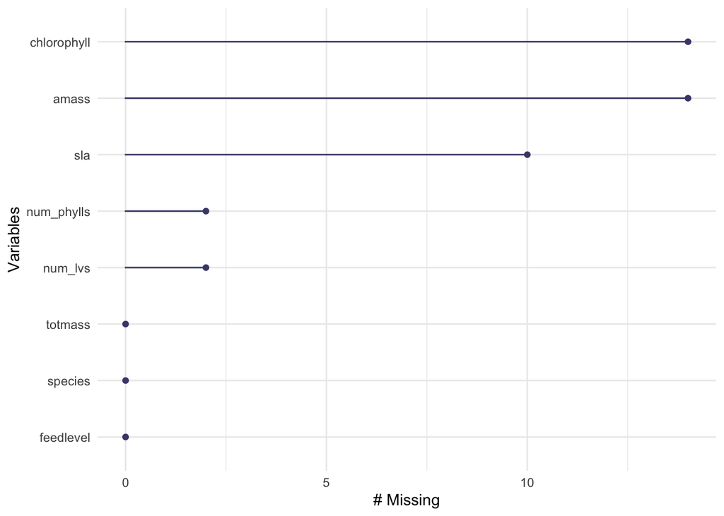

```r
plant <- read_csv(here("data", "knb-lter-hfr.109.18","hf109-01-sarracenia.csv")) %>%
  # make column names cleaner
  clean_names() %>%
  # select columns of interest
  select(totmass, species, feedlevel, sla, chlorophyll, amass, num_lvs, num_phylls)
gg_miss_var(plant)
```

subset dropping NA

```r
plant_subset <- plant %>%
  drop_na(sla, chlorophyll, amass, num_phylls, num_lvs)
```

create a correlation plot

“to determine the relationships between numerical variables in our dataset, we calculated pearsons r and visually represented correlation using a correlation plot”

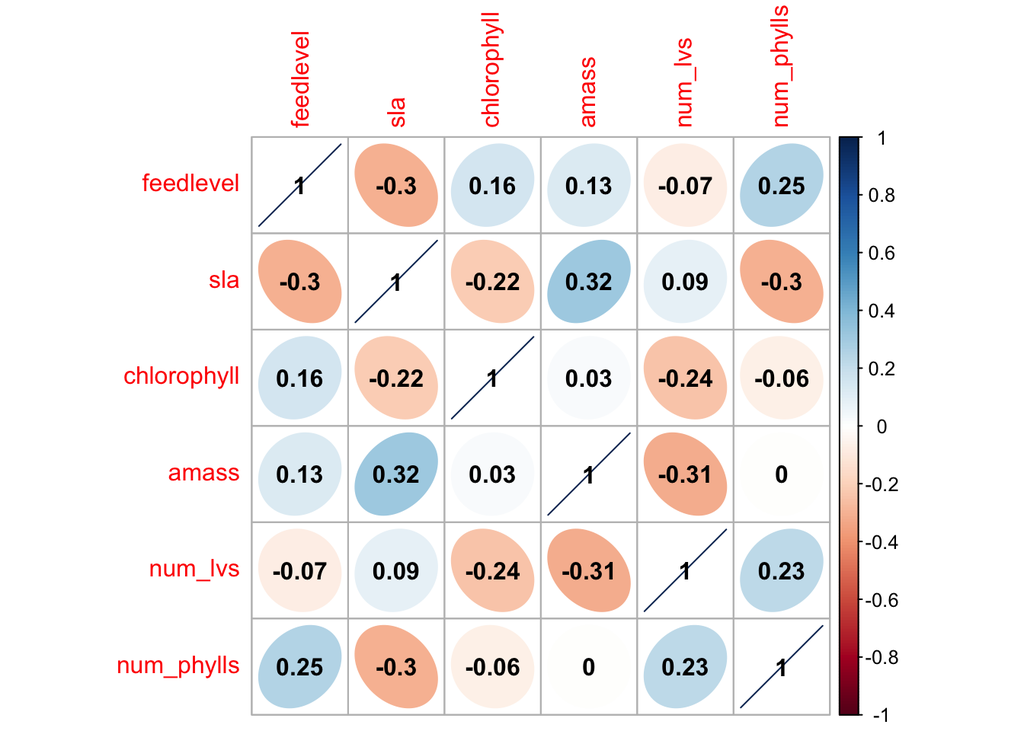

```r
# calculate Pearson's r for numerical values only
plant_cor <- plant_subset %>%
  select(feedlevel:num_phylls) %>%
  cor(method = "pearson")
#returns matrix of numerical values

#create a correlation plot
corrplot(plant_cor,
         #change shape of cells
         method = "ellipse",
         addCoef.col = "black")
```

```r
#don't include two predictors (eg mass) because can conflate r^2
```

create a plot of each variable compared against others

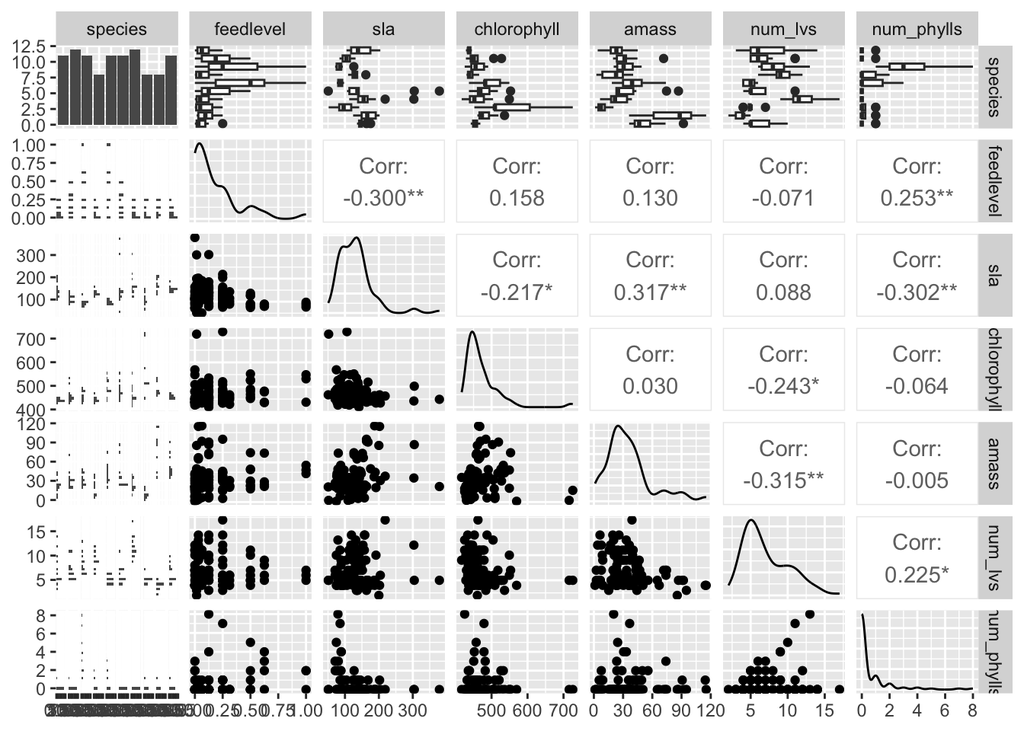

```r
#pair plot can include categorical measurement
plant_subset %>%
  select(species:num_phylls) %>%
  ggpairs()
```

starting regression here: “to determine how species and physiological characters predict bimass, we fit multiple linear models”

```r
# null = no predictors
null <- lm(totmass ~ 1, data = plant_subset)
# full = response and all potential predictors
full <- lm(totmass ~ species + feedlevel + sla + chlorophyll + amass + num_lvs + num_phylls, data = plant_subset)
```

we visually asses normality and homoskedasticity of residuals using diagnostic plots for full model

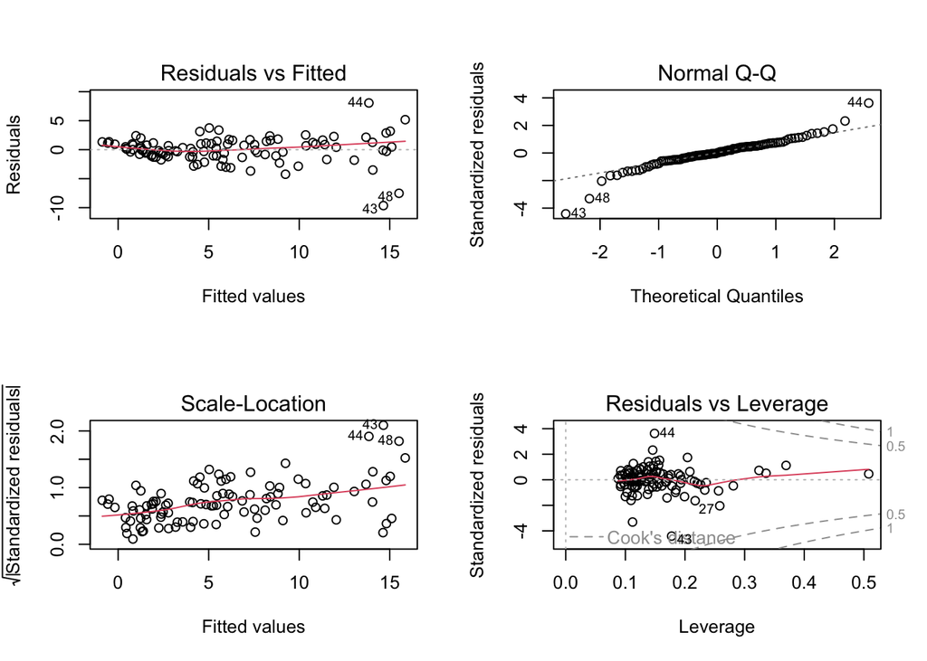

```r
par(mfrow = c(2,2))
plot(full)
```

We also tested for normality using Shapiro-Wilk test (null: variable of interest (ie residuals) are normally distributed). We tested for heteroskedasticity using Breusch-Pagan test (null: variable of interest has constant variance)

```r
check_normality(full)
check_heteroscedasticity(full)
```

[output not shown]

Non-normality & Heteroscedasticity; Assumptions of linear regression are not met!

mathematical transformation can make data betta (only transform response, predictors can stay on the same scale)

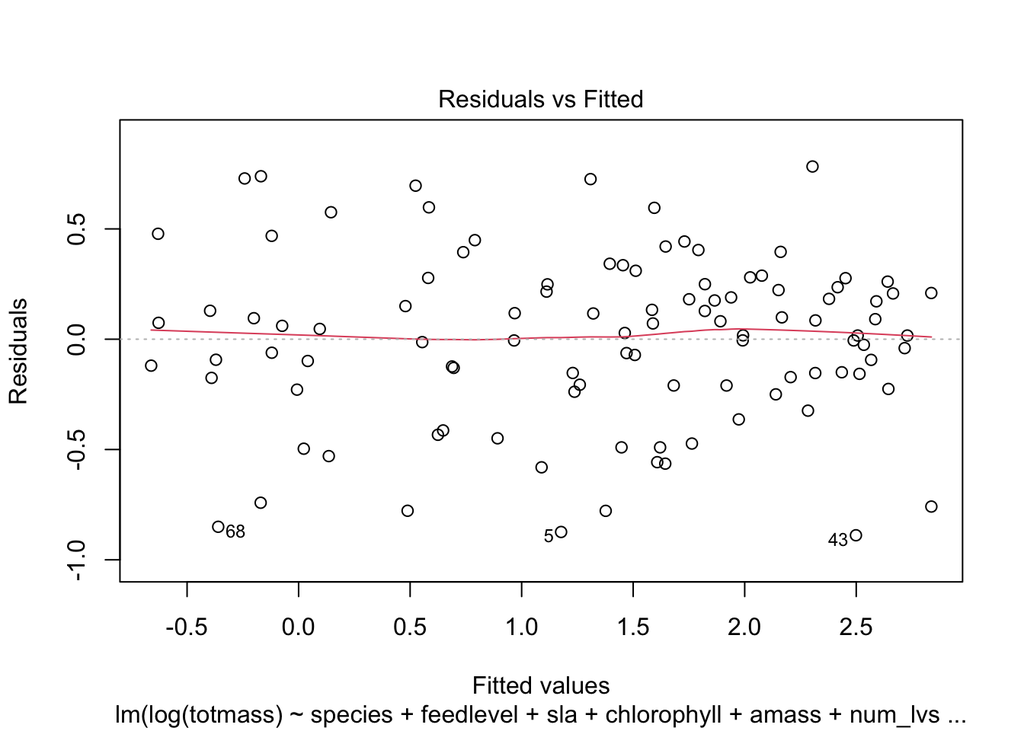

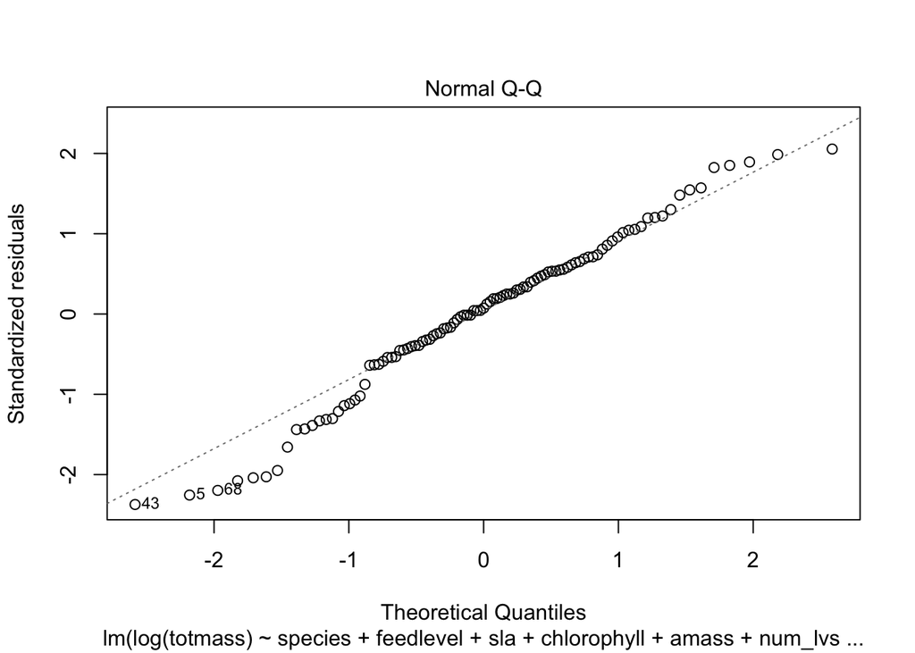

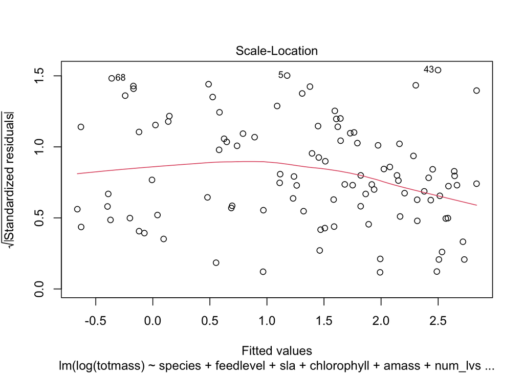

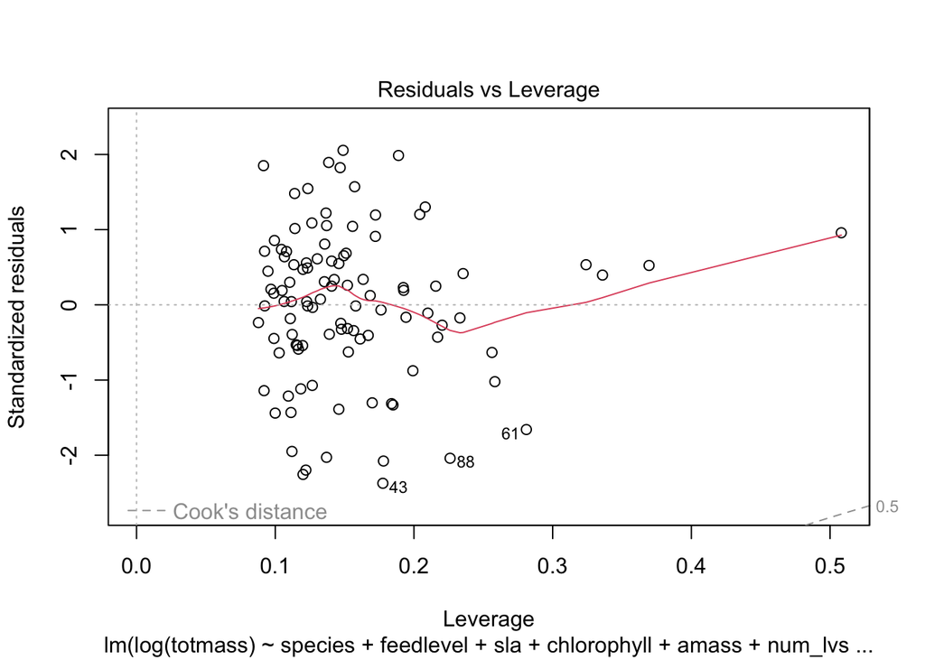

```r
# log transform response
null_log <- lm(log(totmass) ~ 1, data = plant_subset)
full_log <- lm(log(totmass) ~ species + feedlevel + sla + chlorophyll + amass + num_lvs + num_phylls, data = plant_subset)

plot(full_log)
```

check normality of full model with log transform

```r
# do any combo of predictors inflate the data (because they're related)
check_normality(full_log)
```

```
## OK: residuals appear as normally distributed (p = 0.107).
```

```r
check_heteroscedasticity(full_log)
```

```
## OK: Error variance appears to be homoscedastic (p = 0.071).
```

they’re good now! meeting assumption on linear regression all interpretation will be based on a transformed response

Evaluate multicolinearity

```r
car::vif(full_log)
```

```
##                  GVIF Df GVIF^(1/(2*Df))
## species     42.351675  9        1.231351
## feedlevel    1.621993  1        1.273575
## sla          1.999989  1        1.414210
## chlorophyll  1.949828  1        1.396362
## amass        2.872084  1        1.694722
## num_lvs      2.813855  1        1.677455
## num_phylls   2.995510  1        1.730754
```

We evaluated multcol by calculating generalized variance inflation factor and determined that there are no related predictors which inflate the data.

try some models addressing question: what set of predictor variables best explains the response

```r
# species predicts biomass?

model2_log <- lm(log(totmass) ~ species, data = plant_subset)
```

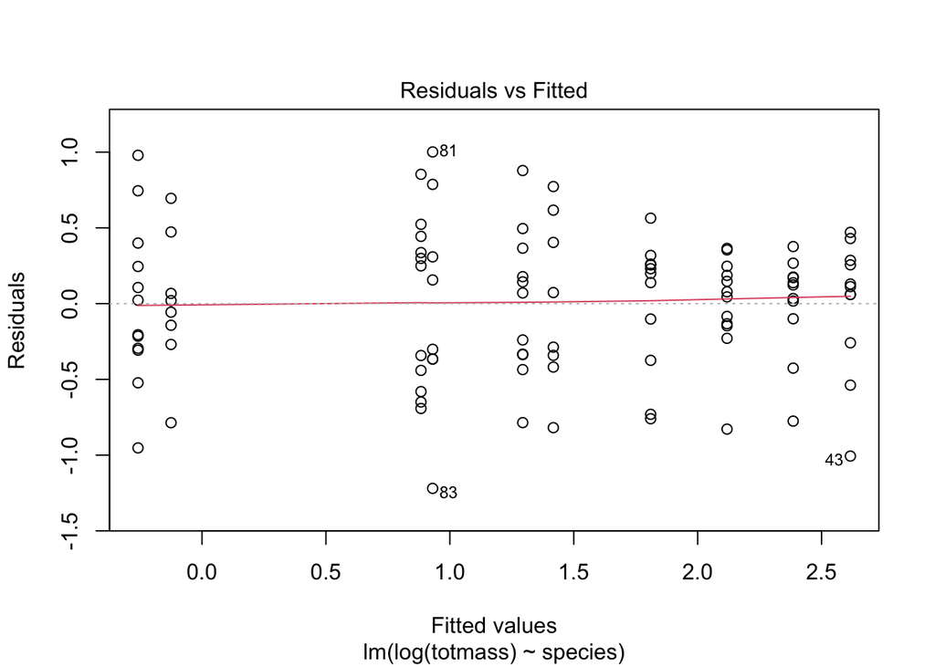

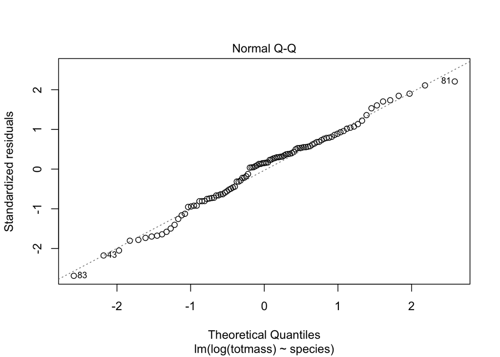

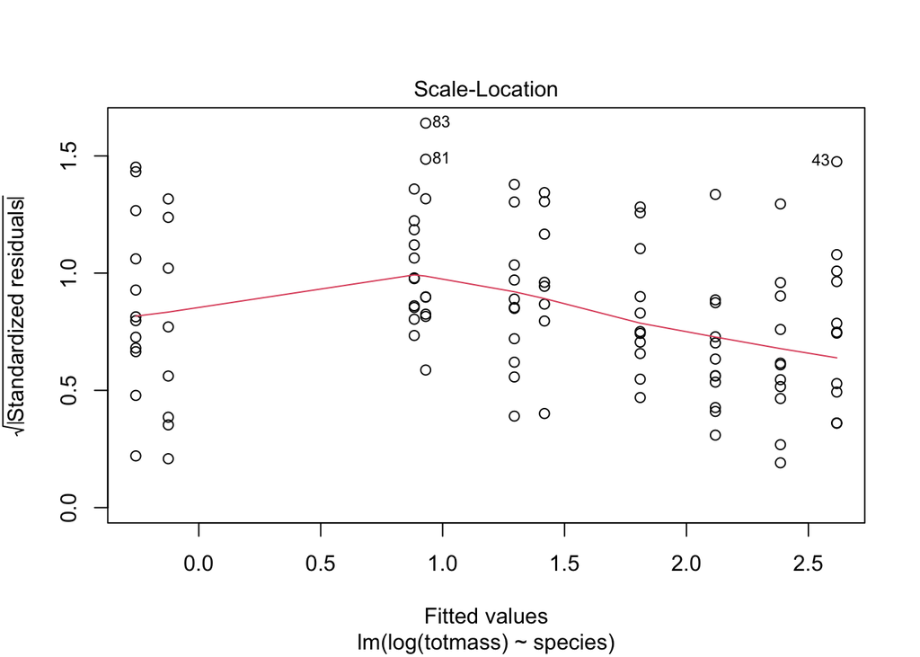

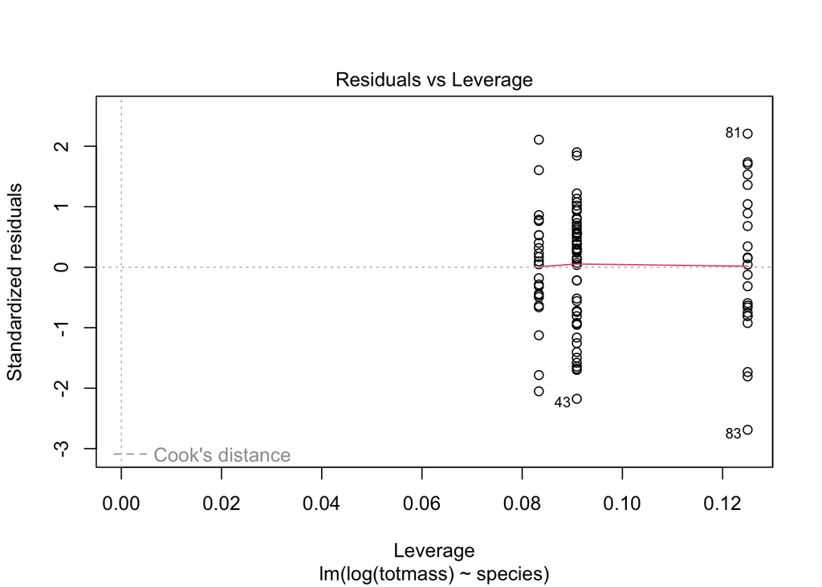

```r
# check assumptions for model

plot(model2_log)
```

```r
# clumps = predictor categorical, all good

check_normality(model2_log)
```

```
## OK: residuals appear as normally distributed (p = 0.374).
```

```r
check_heteroscedasticity(model2_log)
```

```
## OK: Error variance appears to be homoscedastic (p = 0.100).
```

```r
# conforms to assumptions of linear regression!
```

compare models using Akaike Info Criterion (AIC) values: (looks for the simplest model that explains the most variance)

```r
AICc(full_log)
```

```
## [1] 133.9424
```

```r
AICc(model2_log)
```

```
## [1] 157.5751
```

```r
AICc(null_log)
```

```
## [1] 306.0028
```

```r
# least complex model that best predicts the response is full model (lowest value)
```

```r
MuMIn::AICc(full_log, model2_log, null_log)
```

```
##            df     AICc
## full_log   17 133.9424
## model2_log 11 157.5751
## null_log    2 306.0028
```

```r
# if you want to do them all at once

MuMIn::model.sel(full_log, model2_log, null_log)
```

```
## Model selection table
##              (Int)      ams      chl     fdl num_lvs  num_phy       sla spc df
## full_log   -1.3390 0.002338 0.004368 -0.4743 0.09176 -0.03959 -0.002493   + 17
## model2_log  0.8836                                                        + 11
## null_log    1.3500                                                           2
##              logLik  AICc  delta weight
## full_log    -46.371 133.9   0.00      1
## model2_log  -66.337 157.6  23.63      0
## null_log   -150.941 306.0 172.06      0
## Models ranked by AICc(x)
```

```r
# more info, yay!
```

# Results

```r
summary(full_log)
```

```
##
## Call:
## lm(formula = log(totmass) ~ species + feedlevel + sla + chlorophyll +
##     amass + num_lvs + num_phylls, data = plant_subset)
##
## Residuals:
##      Min       1Q   Median       3Q      Max
## -0.88872 -0.20811  0.02825  0.24218  0.78287
##
## Coefficients:
##                     Estimate Std. Error t value Pr(>|t|)
## (Intercept)        -1.339043   0.597727  -2.240 0.027624 *
## speciesalata        1.113163   0.184021   6.049 3.56e-08 ***
## speciesflava        1.404562   0.262955   5.341 7.29e-07 ***
## speciesjonesii      0.319652   0.196426   1.627 0.107281
## speciesleucophylla  1.709035   0.227608   7.509 4.88e-11 ***
## speciesminor        0.389310   0.187903   2.072 0.041239 *
## speciespsittacina  -1.645198   0.207035  -7.946 6.36e-12 ***
## speciespurpurea    -0.364348   0.254380  -1.432 0.155643
## speciesrosea       -0.947383   0.260495  -3.637 0.000467 ***
## speciesrubra        0.875342   0.196361   4.458 2.46e-05 ***
## feedlevel          -0.474255   0.234493  -2.022 0.046199 *
## sla                -0.002493   0.001160  -2.149 0.034430 *
## chlorophyll         0.004368   0.001189   3.672 0.000414 ***
## amass               0.002338   0.002988   0.782 0.436166
## num_lvs             0.091764   0.022413   4.094 9.46e-05 ***
## num_phylls         -0.039585   0.051714  -0.765 0.446068
## ---
## Signif. codes:  0 '***' 0.001 '**' 0.01 '*' 0.05 '.' 0.1 ' ' 1
##
## Residual standard error: 0.413 on 87 degrees of freedom
## Multiple R-squared:  0.8687, Adjusted R-squared:  0.8461
## F-statistic: 38.38 on 15 and 87 DF,  p-value: < 2.2e-16
```

```r
table <- tidy(full_log, conf.int = TRUE) %>%
  #change the p-value numbers if they tiny (>0.001)
  # change est, SE, and t-stat to round to
  #using mutate
  #make into flex table
  flextable() %>%
  #fit it to viewer
  autofit()


table
```

| term | estimate | std.error | statistic | p.value | conf.low | conf.high |
| --- | --- | --- | --- | --- | --- | --- |
| (Intercept) | -1.339043200 | 0.597726532 | -2.2402271 | 0.027624109607483009 | -2.527089405 | -0.1509969955 |
| speciesalata | 1.113162580 | 0.184020930 | 6.0491086 | 0.000000035633453091 | 0.747401056 | 1.4789241035 |
| speciesflava | 1.404562038 | 0.262954818 | 5.3414577 | 0.000000728606298866 | 0.881910865 | 1.9272132117 |
| speciesjonesii | 0.319652351 | 0.196426010 | 1.6273423 | 0.107280978897063520 | -0.070765614 | 0.7100703152 |
| speciesleucophylla | 1.709035391 | 0.227608275 | 7.5086698 | 0.000000000048774953 | 1.256639298 | 2.1614314841 |
| speciesminor | 0.389310367 | 0.187903472 | 2.0718636 | 0.041239074384119417 | 0.015831871 | 0.7627888636 |
| speciespsittacina | -1.645197874 | 0.207034720 | -7.9464830 | 0.000000000006356134 | -2.056701798 | -1.2336939506 |
| speciespurpurea | -0.364347584 | 0.254380246 | -1.4322951 | 0.155642631385408292 | -0.869955868 | 0.1412607001 |
| speciesrosea | -0.947383285 | 0.260494896 | -3.6368593 | 0.000466976667424192 | -1.465145097 | -0.4296214723 |
| speciesrubra | 0.875341885 | 0.196361315 | 4.4578123 | 0.000024573993550445 | 0.485052508 | 1.2656312619 |
| feedlevel | -0.474255269 | 0.234492879 | -2.0224719 | 0.046198841611705246 | -0.940335257 | -0.0081752817 |
| sla | -0.002493083 | 0.001160230 | -2.1487826 | 0.034429589763780563 | -0.004799167 | -0.0001869994 |
| chlorophyll | 0.004368330 | 0.001189484 | 3.6724575 | 0.000414110175835848 | 0.002004101 | 0.0067325586 |
| amass | 0.002337656 | 0.002988210 | 0.7822929 | 0.436166480376765753 | -0.003601736 | 0.0082770479 |
| num_lvs | 0.091763935 | 0.022413350 | 4.0941643 | 0.000094562482452723 | 0.047214976 | 0.1363128941 |
| num_phylls | -0.039585071 | 0.051713890 | -0.7654630 | 0.446067519262093981 | -0.142372027 | 0.0632018848 |

back transform estimates by exponentiating (because we took log)

```r
model_pred <- ggpredict(full_log, terms = "species", back.transform = TRUE)
```

```
## Model has log-transformed response. Back-transforming predictions to
##   original response scale. Standard errors are still on the log-scale.
```

```r
# reporting results in original variable is fine if you tell ppl that

# "log transformed to meet assumptions, back transformed for ease of communication of results"
```

```r
model_pred
```

[output not shown]

all else held constant, we would expect total mass to be around predicted +/- CI.

```
## Model has log-transformed response. Back-transforming predictions to
##   original response scale. Standard errors are still on the log-scale.
```

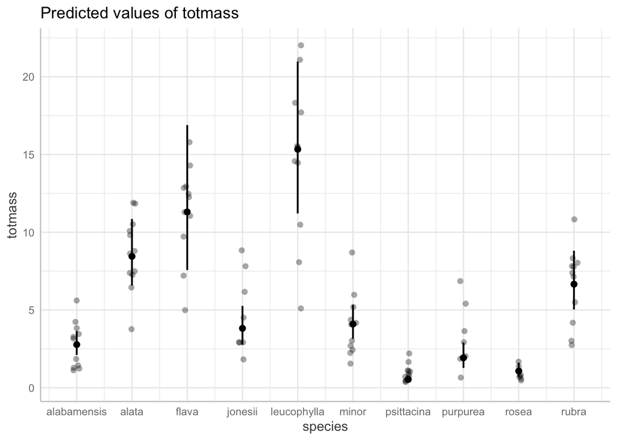

```r
# plot to visualize relationships in data (can choose significant from summary(full_log))
plot(ggpredict(full_log, terms = "species", back.transform = TRUE), add.data = TRUE)
```

```
## Model has log-transformed response. Back-transforming predictions to
##   original response scale. Standard errors are still on the log-scale.
```

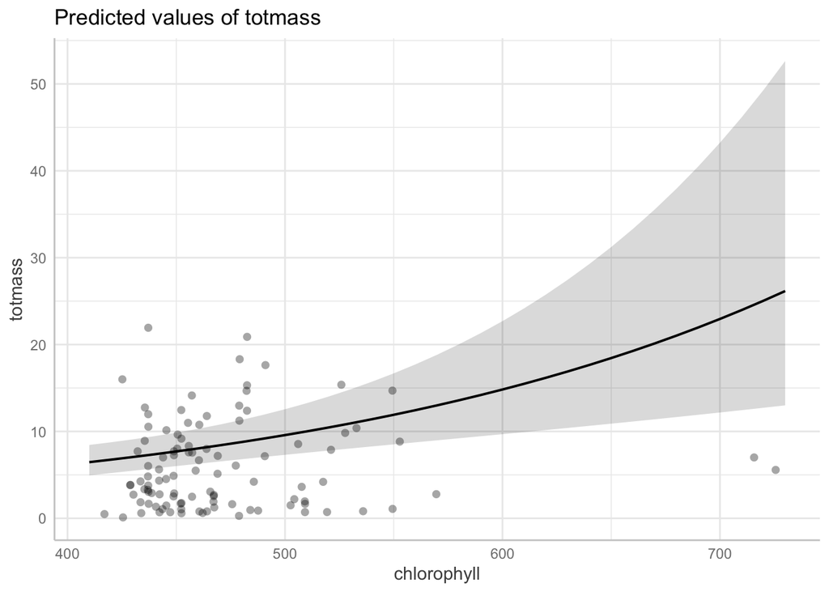

```r
plot(ggpredict(full_log, terms = "chlorophyll", back.transform = TRUE), add.data = TRUE)
```

```r
# choose which figure best represents the main take away of your analysis
```

# different types of ANOVA

type 1: order matter; species > feed level > etc type 2: order doesnt mateer but there may be interaction type 3: order and interaction matters